# DS6306 Case Study 01

Will Rogers, Lauren Nelson

6/26/2021

# Introduction

There are a number of breweries, and thus beers, throughout the United States. These breweries will produce different styles of beer each in their own potentially unique style. However, one can logically expect for there to be trends in the regional tendencies of these breweries. It is an advantage to understand these tendencies so that scarce resources are effectively utilized and strategies created that will bring the maximum returns.

# Data

THe data from this analysis comes from two different datasets, one that contains beer information and one that contains brewery information. These datasets will be merged into one for the purposes of this analysis.

Below is the first few entries from the combined data set.

```
##   Brewery_id        Name.x Beer_ID   ABV IBU
## 1          1  Get Together    2692 0.045  50
## 2          1 Maggie's Leap    2691 0.049  26
## 3          1    Wall's End    2690 0.048  19
## 4          1       Pumpion    2689 0.060  38
## 5          1    Stronghold    2688 0.060  25
## 6          1   Parapet ESB    2687 0.056  47
##                                 Style Ounces             Name.y        City
## 1                        American IPA     16 NorthGate Brewing  Minneapolis
## 2                  Milk / Sweet Stout     16 NorthGate Brewing  Minneapolis
## 3                   English Brown Ale     16 NorthGate Brewing  Minneapolis
## 4                         Pumpkin Ale     16 NorthGate Brewing  Minneapolis
## 5                     American Porter     16 NorthGate Brewing  Minneapolis
## 6 Extra Special / Strong Bitter (ESB)     16 NorthGate Brewing  Minneapolis
##   State fips
## 1    MN   27
## 2    MN   27
## 3    MN   27
## 4    MN   27
## 5    MN   27
## 6    MN   27
```

Now the last few entries are shown.

```
##      Brewery_id                    Name.x Beer_ID   ABV IBU
## 2405        556             Pilsner Ukiah      98 0.055  NA
## 2406        557  Heinnieweisse Weissebier      52 0.049  NA
## 2407        557           Snapperhead IPA      51 0.068  NA
## 2408        557         Moo Thunder Stout      50 0.049  NA
## 2409        557         Porkslap Pale Ale      49 0.043  NA
## 2410        558 Urban Wilderness Pale Ale      30 0.049  NA
##                        Style Ounces                        Name.y          City
## 2405         German Pilsener     12         Ukiah Brewing Company         Ukiah
## 2406              Hefeweizen     12       Butternuts Beer and Ale Garrattsville
## 2407            American IPA     12       Butternuts Beer and Ale Garrattsville
## 2408      Milk / Sweet Stout     12       Butternuts Beer and Ale Garrattsville
## 2409 American Pale Ale (APA)     12       Butternuts Beer and Ale Garrattsville
## 2410        English Pale Ale     12 Sleeping Lady Brewing Company     Anchorage
##      State fips
## 2405    CA   06
## 2406    NY   36
## 2407    NY   36
## 2408    NY   36
## 2409    NY   36
## 2410    AK   02
```

Finally, a random sample of entries.

```
##      Brewery_id                           Name.x Beer_ID   ABV IBU
## 1164        197      Goose Island India Pale Ale    2198 0.059  55
## 1469        280                     Backyahd IPA     983 0.060  NA
## 1027        170         Aviator Raspberry Blonde    2293 0.049  25
## 473          70 Porter (a/k/a Black Gold Porter)    2509 0.060  23
## 1956        394             Gator Tail Brown Ale    1507 0.053  30
## 65           11                     Beach Patrol    2499 0.065  NA
## 1163        196                Post Time KÃ¶lsch    2204 0.050  NA
## 571          85            Widow Maker Black Ale      60    NA  NA
## 2241        492                 Deadicated Amber     924 0.054  27
## 980         166      Frosted Fields Winter Wheat     615 0.060  25
##                         Style Ounces                        Name.y         City
## 1164             American IPA     12  Goose Island Brewery Company      Chicago
## 1469             American IPA     12     Foolproof Brewing Company    Pawtucket
## 1027      American Blonde Ale     12 Crooked Fence Brewing Company  Garden City
```

[output cut: 18 more lines]

# Breweries by State

The first thing analyzed for this data set in the number of breweries in each state. The map below shows how many breweries were counted in each state.

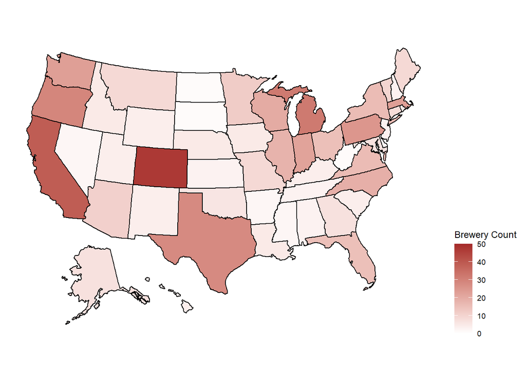

Given that beer is not something new, this plot can also be looked at as a measure of the diversity of beer drinkers in each state.  
Below, the five states the highest brewery count are pulled out for easy reference.

```
##   State  n
## 1    CO 47
## 2    CA 39
## 3    MI 32
## 4    OR 29
## 5    TX 28
```

The states with the fewest breweries have also been pulled out. There are 8 total because of four-way tie for fifth fewest breweries.

```
##   State n
## 1    DC 1
## 2    ND 1
## 3    SD 1
## 4    WV 1
## 5    AR 2
## 6    DE 2
## 7    MS 2
## 8    NV 2
```

Base on the visual evidence there is not an even distribution of breweries among the states. Starting with the highest ranking state (Colorado) and moving down the list, the below plot shows how which states the data under analysis is coming from.

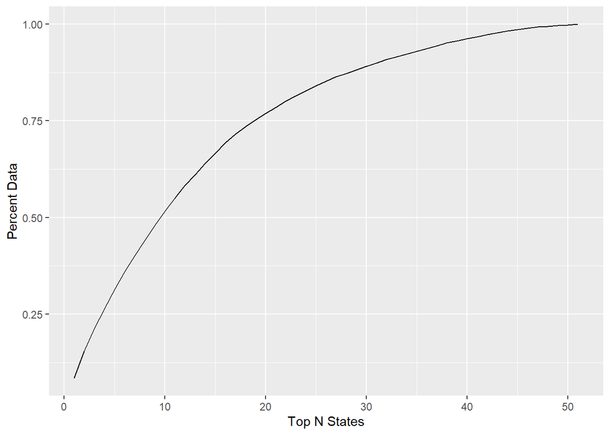

# Alcohol Content, Bitterness by State

Two of the defining characteristics of beer is the alcohol content and the bitterness. The measure of these things are ABV and IBU respectively.

## Alcohol Content

Before analyzing the data, it needs to be noted that not every entry in the data set had an ABV entry. The below plot shows the valid data for each state.

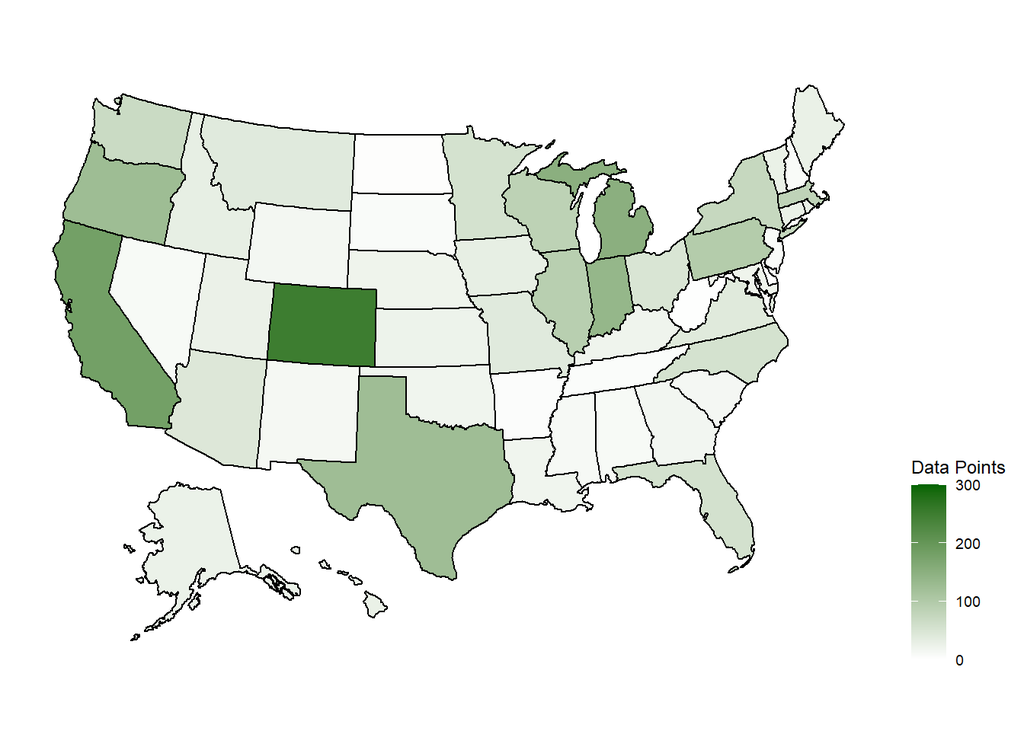

Given a relatively few data entries are missing ABV data, the entries will simply be excluded from any analysis that uses ABV. THe first analysis is how alcohol content breaks down by state. Below we can see a map of how the median ABV content is distributed by state.

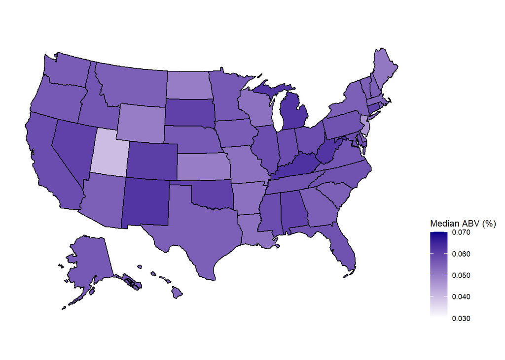

As another comparison, the same data is shown again in bar chart format.

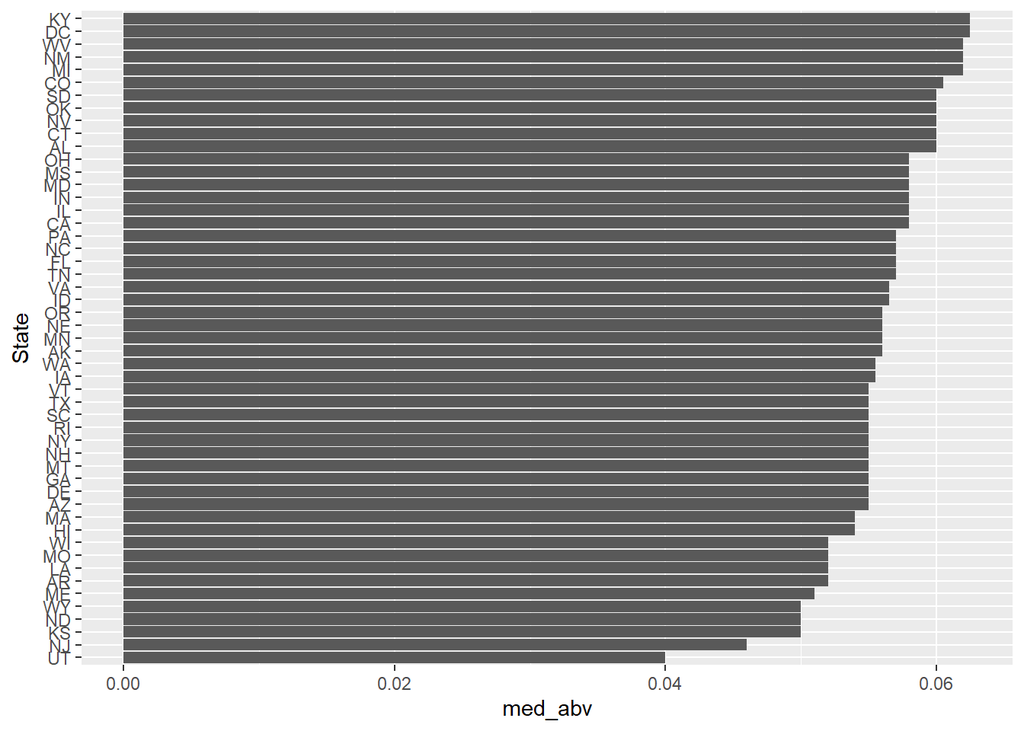

## Summary Stats

```
##    Min. 1st Qu.  Median    Mean 3rd Qu.    Max.    NA's
## 0.00100 0.05000 0.05600 0.05977 0.06700 0.12800      62
```

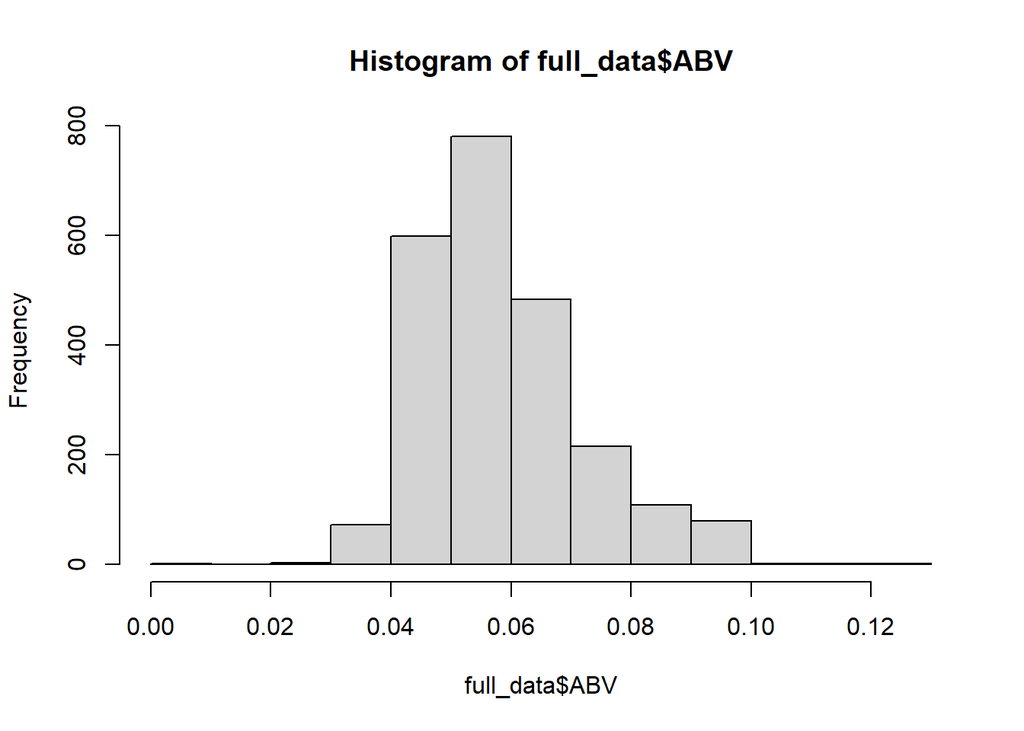

## Bitterness Content

As the second primary characteristic of any particular beer, a similar analysis to IBU was done

Below the states with the number of beers with IBU scores for each state are shown. States with below 15 ratings are grayed out to highlight them as states with a low amount of data. Another way to view this chart is as the states the are the primary influences of any further analysis that uses IBU score. This important to note because any missing data was removed from from further analysis.

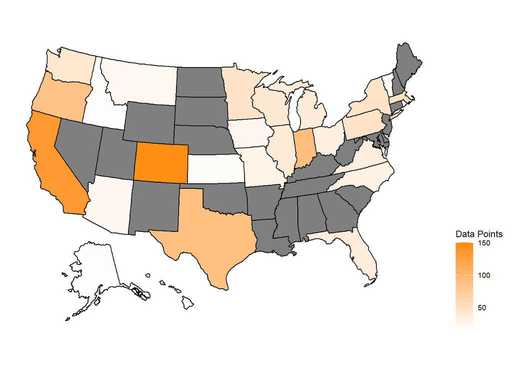

Similar to ABV, the median IBU for each state is shown as the color axis on a map of the United States. Note that South Dakota does not have any valid data.

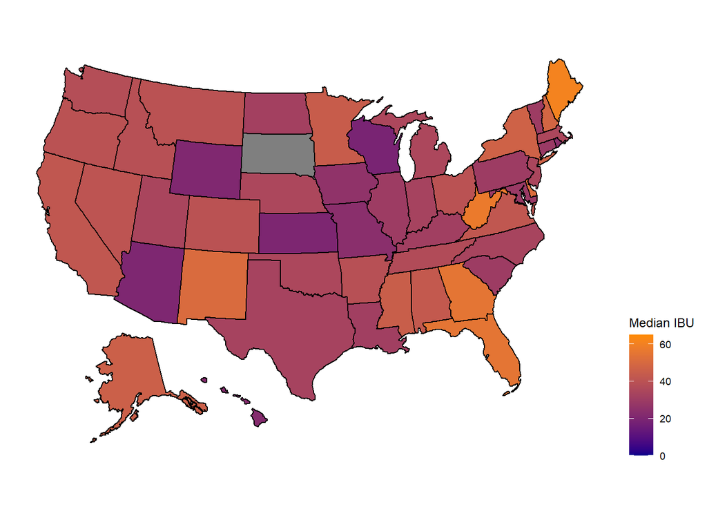

Again, the same information as above in a bar chart format.

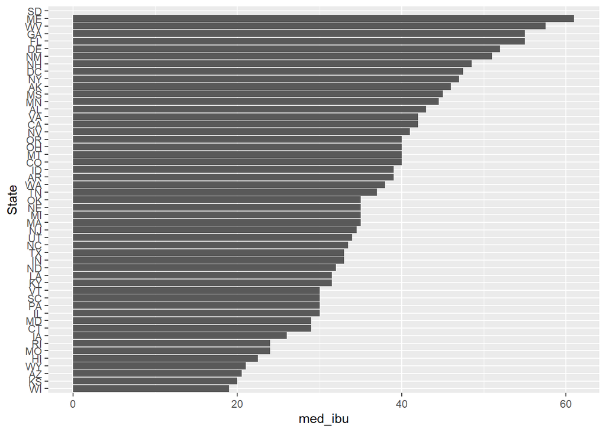

## Noteworthy States

The state with the single beer that has the maximum ABV

```
## [1] " CO"
```

The state with the single beer that has the maximum IBU

```
## [1] " OR"
```

# Alcohol Content and Bitterness Relationship

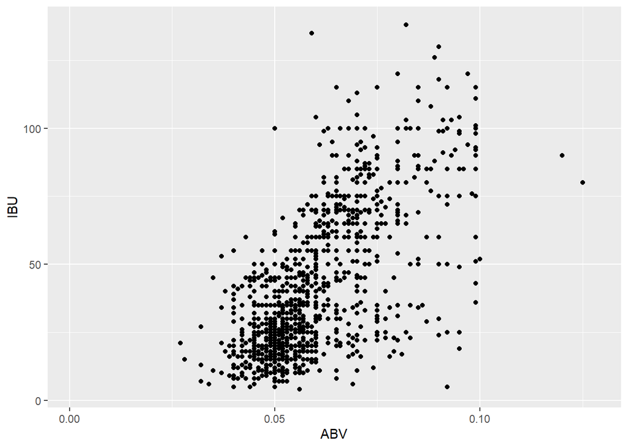

There appears to a positive correlation between ABV and IBU. This makes sense since one of the primary source of bitterness is the hop, which gets added in greater quantities as the alcohol content goes up to offset the taste.

# Ale Classification by Alcohol Content and Bitterness

Given the desire to classify ales as either an IPA or not by their bitterness and alchol content. We need to look at how big of a problem the missing data, particularly IBU data really is. Below each non ale was filtered out of data set. The remaining data points were then classified as either an IPA or not based on the presence of ‘IPA’ in their style entry. Finally as a result of the ABV and IBU being on different scales, each variable was turned into a Z score to since the classification was going to be based on Euclidean distance.

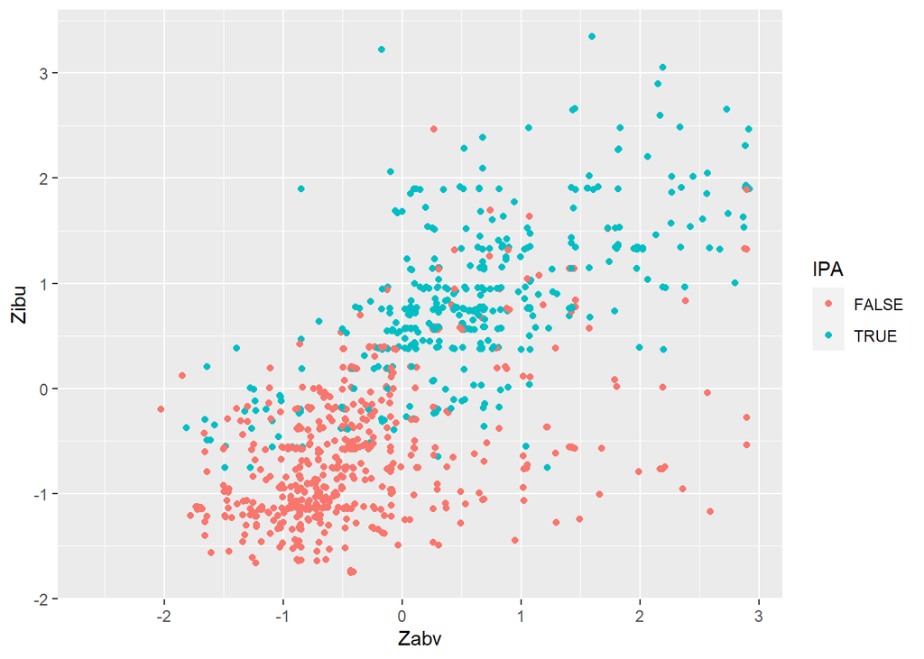

## KNN Classifier

It was determined that a KNN classifier should be used for this analysis. This only left the question of which value of K to use for this problem. Severl values of K were iterated through and the one with the best accuracy was chosen as the final selection. The plot for these values can be seen below.

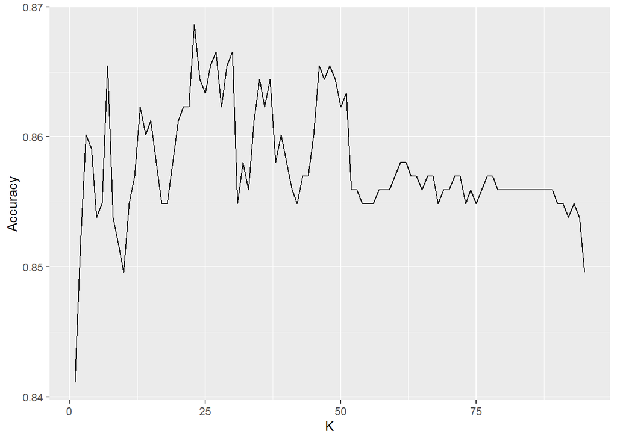

Based on this data the best value for K is

```
## [1] 23
```

Using this selection of K, a classification surface was created that shows how any unknown ale would be classified based on it ABV and IBU score with color axis showing the probability that it would be classified as an IPA

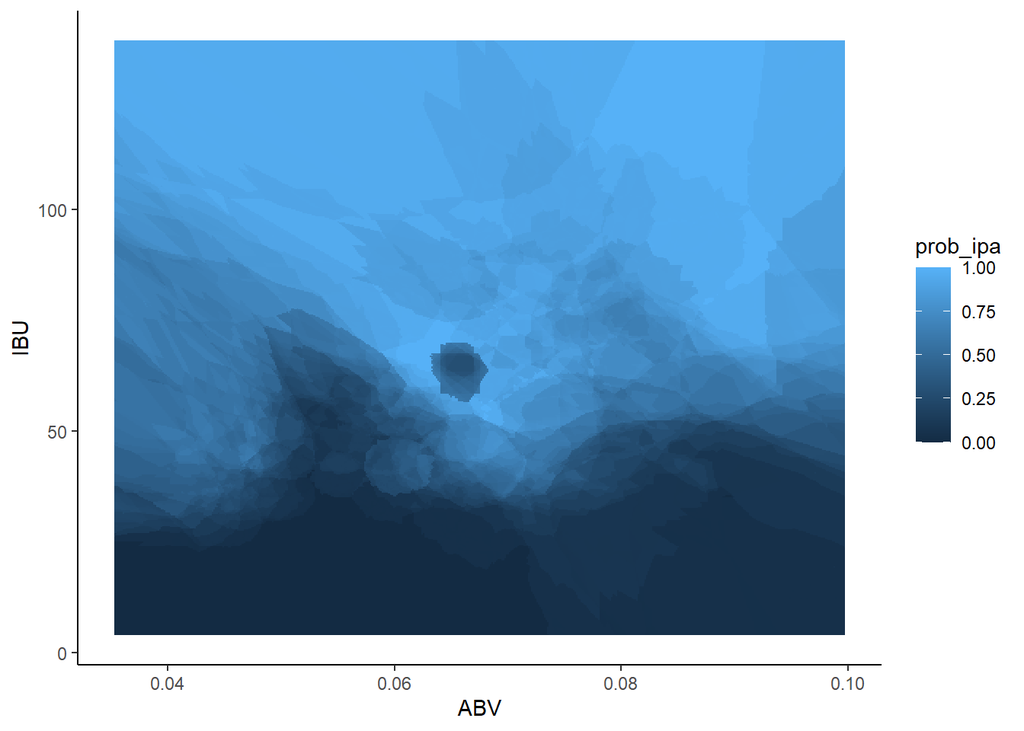

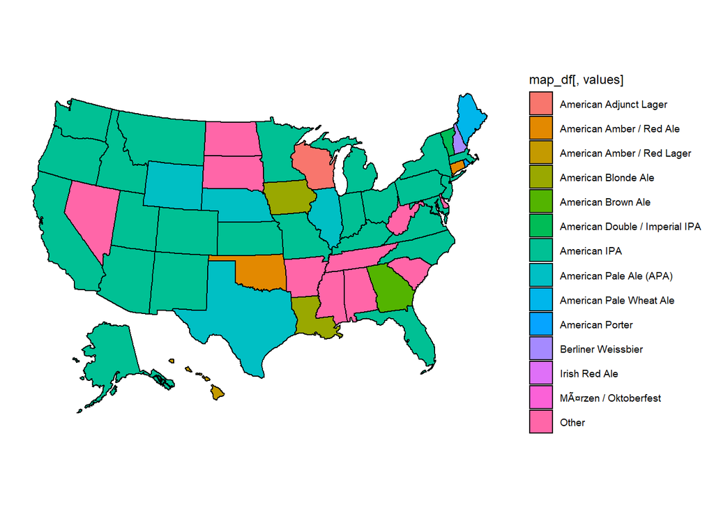

As visually evident the American IPA is the most popular style in the most states. It is also seen the overall Ale style is the most popular broad style of beer in the with a few unique states. It is also interesting that the states are mostly are concentrated in the southeast.

# Conclusion

There are only so many resources that any one company has. It is therefore important to allocated these resources in order to develop the best strategies and the desired return. Here, we have looked at how breweries are distributed across the Unites States, where they are concentrated and where they are scarce. We addressed where out data is coming from and how the missing data for each category was handled so that the limitations of this analysis could be understood and determine the scope of conclusions made. The ABV and IBU scores were compared among the states, as well as their ability to predict whether an ALE is an IPA or not. Finally the distribution of favorite beer style by state was generated to inform the which style of beer is most deserving a resources. Each of one these analysis highlight useful market data to inform resource allocation.